# Session 3 Homework

Try these homework questions to revise the content of session 3.

For this homework, you will be using the mtcars dataset, which is built into R. You can load it with `data(mtcars)`. Try using some of the functions we’ve learned about in sessions 1 and 2 to explore the dataset (like `View()` to open it in a tabular form, or `head()` to show the first six rows). You can also use the `?mtcars` command to read the help page for the dataset.

1. Look at the following ggplot2 code and describe in words what type of plot it will make.

```r
ggplot(data = mtcars,
  aes(x = mpg)) +
  geom_histogram(binwidth = 2, fill = "orange", colour = "red") +
  facet_wrap(~ cyl) +
  labs(title = "Histogram of miles per gallon (mpg) by number of cylinders",
       x = "Miles per gallon (mpg)",
       y = "Count") +
  theme_bw()
```

```r
ggplot(data = mtcars,
  aes(x = mpg, y = wt)) +
  geom_point(aes(size = hp), colour = "blue", alpha = 0.5) +
  geom_smooth(method = "lm", colour = "black") +
  labs(title = "The relationship between miles per gallon (mpg), weight (wt) and horsepower (hp)",
       x = "Miles per gallon (mpg)",
       y = "Weight (wt)",
       size = "Horsepower (hp)") +
  theme_minimal() +
  theme(plot.title = element_text(size = 14, face = "bold", colour = "blue"))
```

*Solution.*

1. This code creates a histogram of the `mpg` (miles per gallon) variable from the `mtcars` dataset. The histogram is faceted by the number of cylinders (`cyl`), meaning that separate histograms will be created for each unique value of `cyl`. The bars of the histogram are filled with orange and outlined in red. The x-axis is labelled “Miles per gallon (mpg)” and the y-axis is labelled “Count”. The overall theme of the plot is set to a black-and-white theme using `theme_bw()`.
2. This code creates a scatterplot/bubble plot of the `mpg` (miles per gallon) variable against the `wt` (weight) variable from the `mtcars` dataset. The points are coloured blue and have an alpha (transparency) of 0.5, and their size is determined by the `hp` (horsepower) variable. A linear regression line is added to the plot using `geom_smooth(method = "lm")`, which is coloured black. The x-axis is labelled “Miles per gallon (mpg)” and the y-axis is labelled “Weight (wt)”. The plot title is “The relationship between miles per gallon (mpg), weight (wt) and horsepower (hp)”, with a font size of 14, bold face, and blue colour. Note the use of the `size` argument in the `labs()` function to label the legend for the size of the points as “Horsepower (hp)”.
2. Write some ggplot2 code that will create:
1. A bar chart of the number of cars in each `cyl` category. Make sure to label the plot.
2. A boxplot of `mpg` by `cyl`, with the boxplot fill colour set to “lightblue” and the outline colour set to “darkblue”. The plot should have a title “Boxplot of miles per gallon (mpg) by number of cylinders”, and the x-axis labelled “Number of cylinders” and the y-axis labelled “Miles per gallon (mpg)”.

Try to make them look as nice as possible, using the techniques we’ve learned in this session.

*Solution.*

1. To create a bar chart of the number of cars in each `cyl` category, you can use the following code:

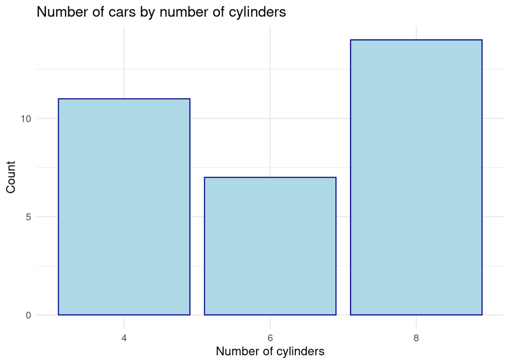

```r
ggplot(data = mtcars,
  # use as.character() to convert cyl to a character variable (can't make bar chart of numeric variable)
  aes(x = as.character(cyl))) +
  # use geom_bar() to create a bar chart
  # choose some nice colours
  geom_bar(fill = "lightblue", colour = "darkblue") +
  # label it
  labs(title = "Number of cars by number of cylinders",
       x = "Number of cylinders",
       y = "Count") +
  # do some styling
  theme_minimal(base_size = 12)
```

2. To create the boxplot described in the question, you can use the following code:

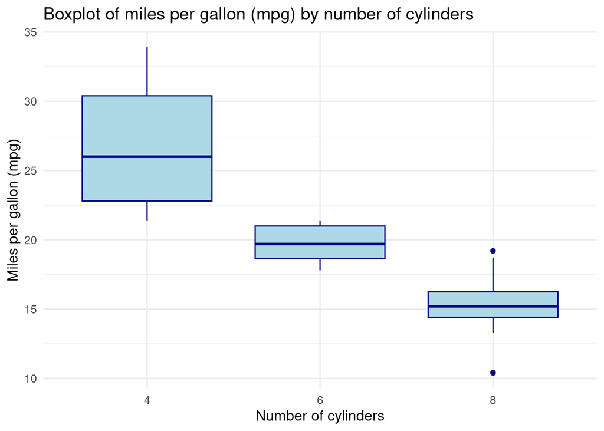

```r
ggplot(data = mtcars,
  aes(x = as.character(cyl), y = mpg)) +
  # use geom_boxplot() to create a boxplot
  # choose some nice colours
  geom_boxplot(fill = "lightblue", colour = "darkblue") +
  # label it
  labs(title = "Boxplot of miles per gallon (mpg) by number of cylinders",
       x = "Number of cylinders",
       y = "Miles per gallon (mpg)") +
  # do some styling
  theme_minimal(base_size = 12)
```

3. I’ve written the following code to try and make a dotplot that shows the relationship between the horsepower of a car and whether it has manual or automatic transmission in the `mtcars` dataset, but it doesn’t work. Can you figure out what the problem is? As a bonus question, why is the `as.logical()` function being used here?

```r
ggplot(data = mtcars,
  aes(x = as.logical(am), y = hp)) +
  geom_point(aes(colour = "magenta", position = position_jitter(0.1), size = 2)) +
  labs(title = "Relationship between horsepower and transmission type",
       x = "Is the car manual?",
       y = "Horsepower") +
  theme_bw()
```

*Solution.*

The problem with the code is that the `aes()` function is not being used correctly to map the aesthetics of the plot. The `position` argument should be passed to the `geom_point()` function instead (it never belongs inside `aes()`) and the colour and size aesthetics shouldn’t be inside `aes()` either as they are just for styling the plot and not related to any variables.

The correct code (and resulting plot) should look like this:

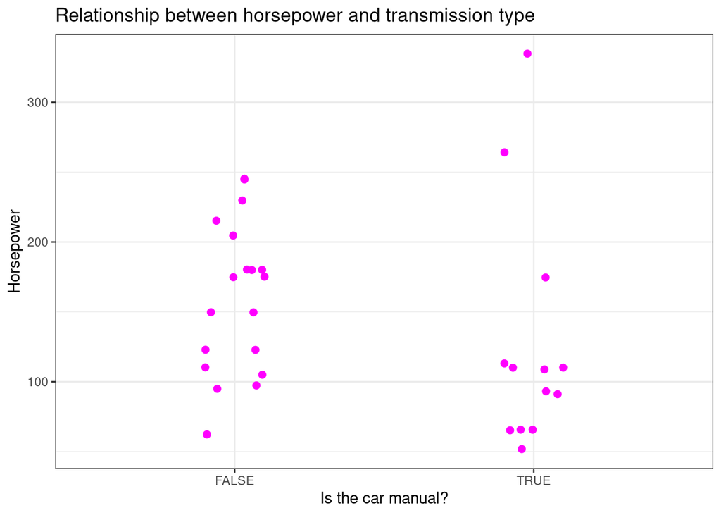

```r
ggplot(data = mtcars,
  aes(x = as.logical(am), y = hp)) +
  geom_point(colour = "magenta", position = position_jitter(0.1), size = 2) +
  labs(title = "Relationship between horsepower and transmission type",
       x = "Is the car manual?",
       y = "Horsepower") +
  theme_bw()
```

The reason we use `as.logical()` is because the `am` variable in the `mtcars` dataset is actually a numeric variable (0 for automatic and 1 for manual), but we want to treat it as a logical variable (automatic vs. manual) because TRUE/FALSE here is more easily interpretable. The `as.logical()` function converts the numeric values to logical values (TRUE or FALSE), which can be used to create a dotplot.

4. Write some code to re-create the plots below in ggplot2.

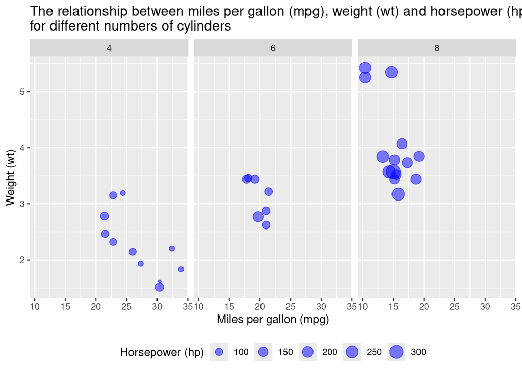

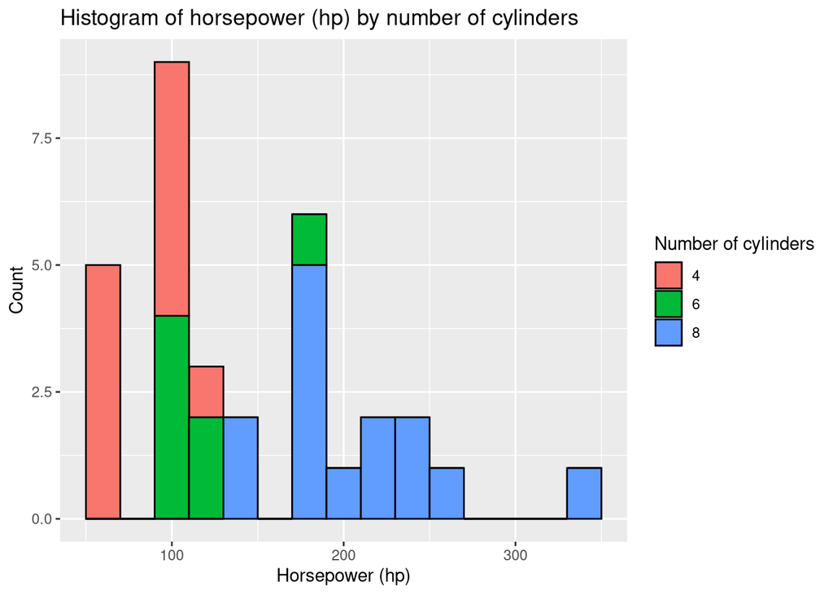

*Solution.*

1. The code to create the first plot is:

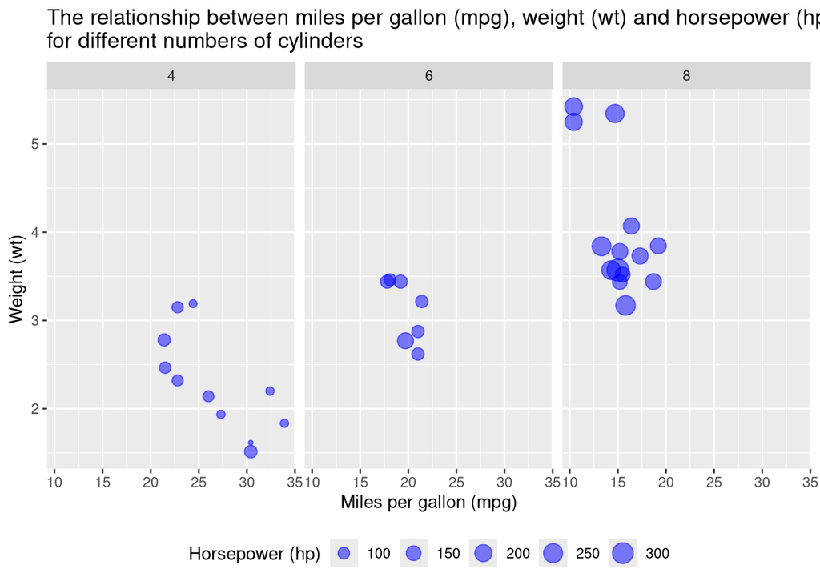

```r
ggplot(data = mtcars,
  aes(x = mpg, y = wt)) +
  geom_point(aes(size = hp), colour = "blue", alpha = 0.5) +
  labs(title = "The relationship between miles per gallon (mpg), weight (wt) and horsepower (hp) \nfor different numbers of cylinders",
       x = "Miles per gallon (mpg)",
       y = "Weight (wt)",
       size = "Horsepower (hp)") +
  facet_wrap(~ cyl) +
  theme(legend.position = "bottom")
```

[figure not shown]

5. Assign the plots you created in question 4 to variables, use the patchwork package to combine them into a single figure (stacked on top of each other and labelled with A and B), and save it to a file.

*Solution.*

Here is some well-commented code that does this:

```r
# first make the plots and assign to variables
# plot A: scatterplot
mpg_wt_scatterplot <- ggplot(data = mtcars,
  aes(x = mpg, y = wt)) +
  geom_point(aes(size = hp), colour = "blue", alpha = 0.5) +
  labs(title = "The relationship between miles per gallon (mpg), weight (wt) and horsepower (hp) \nfor different numbers of cylinders",
       x = "Miles per gallon (mpg)",
       y = "Weight (wt)",
       size = "Horsepower (hp)") +
  facet_wrap(~ cyl) +
  theme(legend.position = "bottom")

# plot B: histogram
hp_histogram <- ggplot(data = mtcars,
  aes(x = hp, fill = as.character(cyl))) +
  geom_histogram(binwidth = 20, colour = "black") +
  labs(title = "Histogram of horsepower (hp) by number of cylinders",
       x = "Horsepower (hp)",
       y = "Count",
       fill = "Number of cylinders")

# now combine the plots using patchwork
# use the / operator to stack them on top of each other
combined_plot <- mpg_wt_scatterplot / hp_histogram +
  # add labels to the plots
  plot_annotation(tag_levels = "A")

# check the combined plot to make sure it looks ok
combined_plot

# save the combined plot to a file
ggsave("combined_plot.png", plot = combined_plot, width = 8, height = 10)
```